# Hate in Context

Week 9: Reducing Hate Crime I — Contact

Violeta Haas

Department of Political Science

School of Social Sciences and Philosophy

Trinity College Dublin

# This Week

1. Reminder
2. Catch-up: Week 8
3. Theoretical Background
4. Alrababa’h et al. (2021)
5. Mousa (2020)
6. Scacco & Warren (2018)
7. Synthesis

# Reminder

## Research proposal (60%)

A proposal for an empirical study (**2,500–3,000 words**):

1. Clear research question
2. Critical literature synthesis
3. Theoretical argument
4. Empirical approach (cases, methods, data)

You do **not** need to carry out the full study. Deadline: Fri 11 Dec, 11:59 pm.

## Research proposal (60%)

A typical table of contents for the research paper might look like this:

1. **Introduction**
2. **Literature review**
3. **Theoretical motivation**
4. **Design**
5. **Data description**
6. **Results**
7. **Interpretation and conclusions**

80%

20%

# Catch-up: Week 8

## Fickle Prosocial Violence Response model

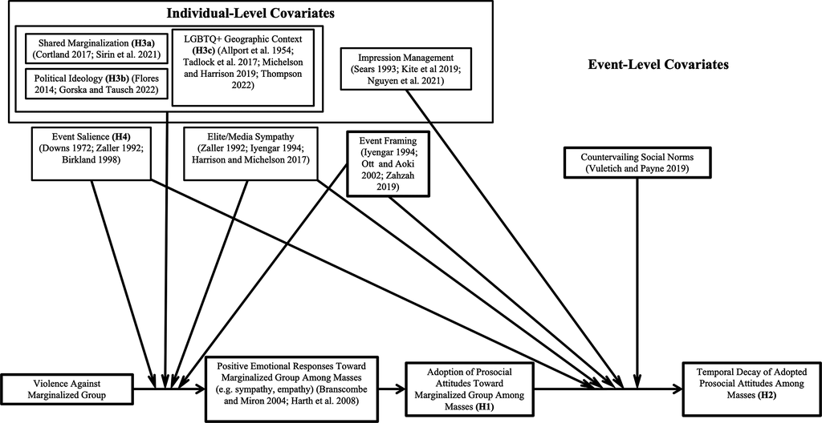

## SSM support increases post-Pulse

**Pulse:** June 2016 massacre at Pulse, an LGBTQ+ nightclub in Orlando

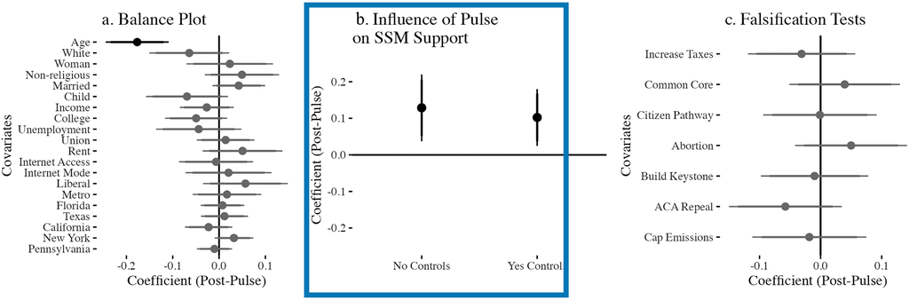

Post-Pulse respondents more supportive of same-sex marriage

## Pulse effect attenuates over time

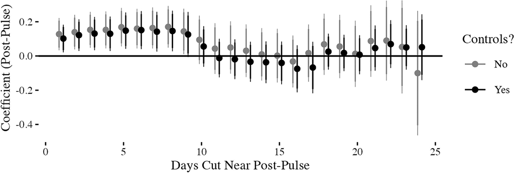

The prosocial shift is short-lived, consistent with the “fickle” FPVR prediction

## Anti-gay attitudes after Pulse

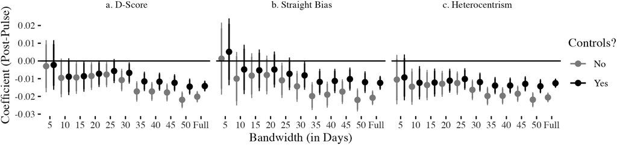

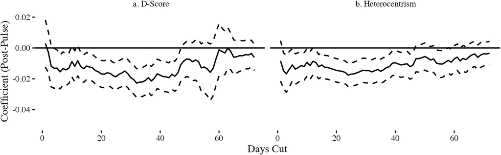

Top: post-Pulse cuts implicit and explicit anti-gay bias (D-score, straight bias, heterocentrism) across bandwidths.  
Bottom: that reduction holds for ~50 days, then fades. Same “fickle” pattern as SSM support

Critique/Open questions?

Local, low-salience crimes by out-group members can spark majority retaliation (Riaz et al. 2024), while majority prosociality toward minorities seems to need highly salient events (Roman and Thompson 2024).

Synthesis

## Exercise: sort the readings

In pairs (≈5 min): place today’s readings. Any earlier required readings that also fit?

whose reaction is observed

Minority group

Majority group

who discriminates/enacts violence

Bottom-up  
hostility

Bottom-up discrimination → minority outcomes

Bottom-up discrimination → majority outcomes

Top-down  
hostility

Top-down discrimination → minority outcomes

Top-down discrimination → majority outcomes

## Exercise: sort the readings

whose reaction is observed

Minority group

Majority group

who discriminates/enacts violence

Bottom-up  
hostility

Bottom-up discrimination → minority outcomes

- **Mitts (2019):** anti-Muslim hostility → online ISIS radicalisation
- **Branton & Kropf (2026):** anti-African American hate crime → vote-by-mail

Bottom-up discrimination → majority outcomes

- **Roman & Thompson (2024):** salient civilian anti-LGBTQ+ violence → short-term prosocial attitudes

Top-down  
hostility

Top-down discrimination → minority outcomes

- **Mitts (2019):** far-right vote share (>15%), i.e., far-right elites in power → online ISIS radicalisation

Top-down discrimination → majority outcomes

- **Romarri (2020):** Italian far-right mayors → hate crimes against immigrants
- **Müller & Schwarz (2023):** Trump’s anti-Muslim tweets → anti-Muslim hate crime
- **Allinger (n.d.):** Italy’s nomad-camp policy → hate crimes against Roma
- **Levy & Levy (2017):** US state gay/lesbian rights policy → anti-LGBT hate crime

# Theoretical Background

## Discussion: contact

**Turn to a neighbor (≈4 min):**

1. What is intergroup contact/parasocial contact, and under what conditions does each reduce prejudice?
2. How does social contact reduce prejudice? What are the mechanisms?
3. Is there contact that backfires? What kind?

What is intergroup contact/parasocial contact, and under what conditions does each reduce prejudice?

## Contact & parasocial contact

**Intergroup contact** (Allport, 1954)

Face-to-face contact across group lines can reduce prejudice when it meets the right conditions:

- Equal status
- Common goals
- Cooperative environment (not pure competition)
- Institutional support (norms/authorities)

**Parasocial contact** (Schiappa et al., 2005)

*Mediated* contact with out-group celebrities or characters can likewise reduce prejudice toward the group as a whole when it involves:

- Repeated exposure
- Positive/likable portrayal
- Salient out-group identity

How does social contact reduce prejudice? What are the mechanisms?

## How contact reduces prejudice

- **Increasing knowledge** about the out-group/debunking negative stereotypes
- **Reducing anxiety** about encounters with out-group members
- **Increasing empathy** and perspective-taking
- **Changing social norms** (normalizing intergroup friendships, …)

Is there contact that backfires? What kind?

## What contact backfires

- **Negative contact** (hostile, unequal, threatening encounters)
- **Competitive contact** (zero-sum rivalry rather than cooperation toward shared goals)
- **Not meaningful contact** — physical/non-verbal proximity only, without real interaction

## Meaningful contact + physical touch

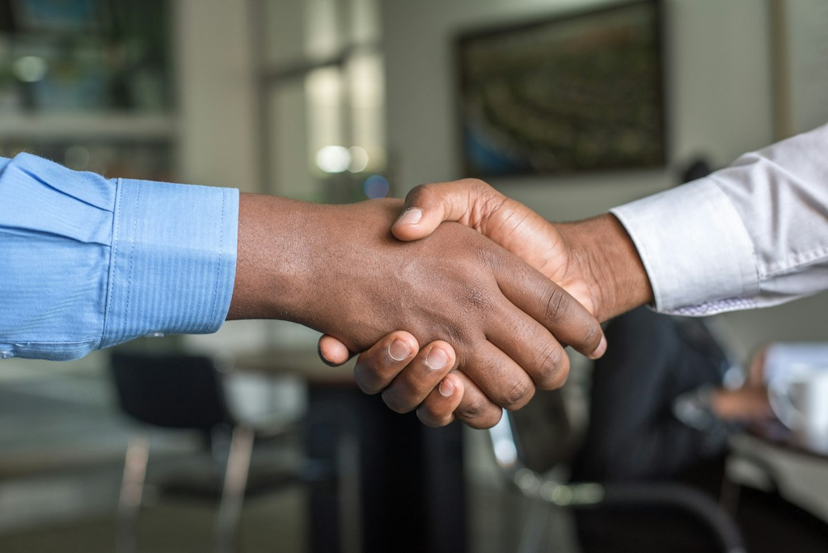

HBS experiments: pairs who shake hands cooperate more and reach better joint deals than pairs who do not.

Schroeder et al. (2019)

# Alrababa’h et al. (2021)

Research Question: Can exposure to celebrities reduce prejudice?

## Experimental design

- **Setting:** Mohamed Salah joins Liverpool FC (June 2017), a highly visible, practicing Muslim star
- **Design:** synthetic control for Merseyside hate crimes, Twitter among LFC fans vs other clubs, and a survey experiment
- **Treatment:** parasocial exposure to a successful, openly Muslim celebrity athlete
- **Outcomes:** hate crimes, anti-Muslim tweets, and survey attitudes toward Islam/Muslims

Does Salah fulfill the criteria for successful parasocial contact?

✓ Repeated exposure  
✓ Positive/likable portrayal  
✓ Salient out-group identity

[figure not shown]

## Figure 1 · Attitudes toward Islam

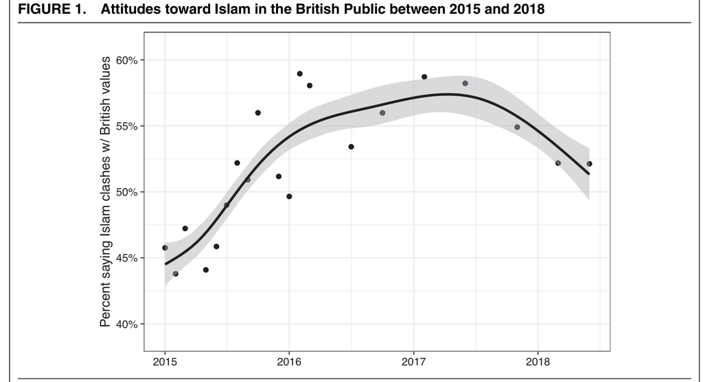

Context: share saying Islam clashes with British values rises through 2015–17, then eases slightly.

## Figure 2a · Hate crimes: observed vs imputed

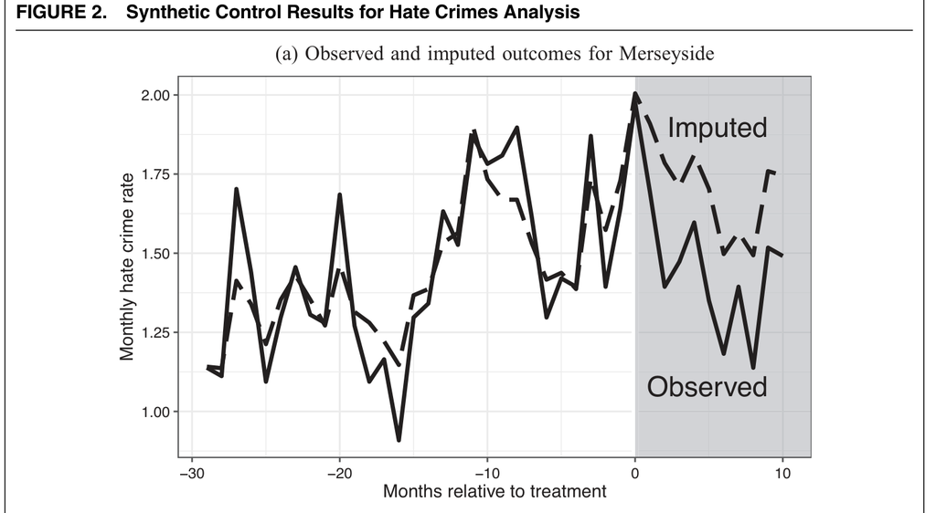

After Salah joins, Merseyside hate crimes fall ~16% below the synthetic (imputed) counterfactual.

## Figure 2b · Hate crimes: treatment vs placebos

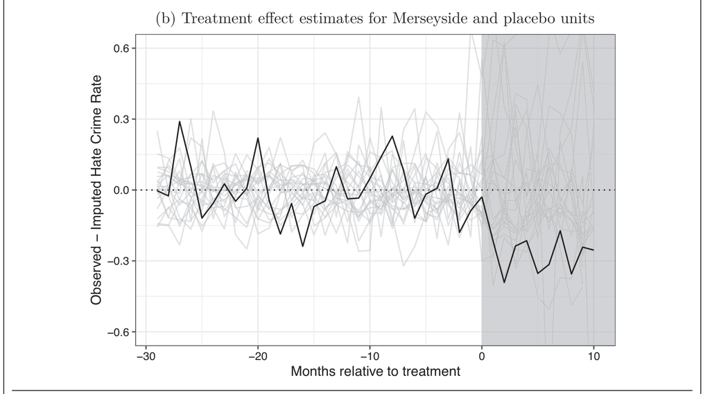

Merseyside’s post-treatment drop stands out against placebo units (other police stations), not a generic UK trend.

## Figure 3 · All crime types in Merseyside

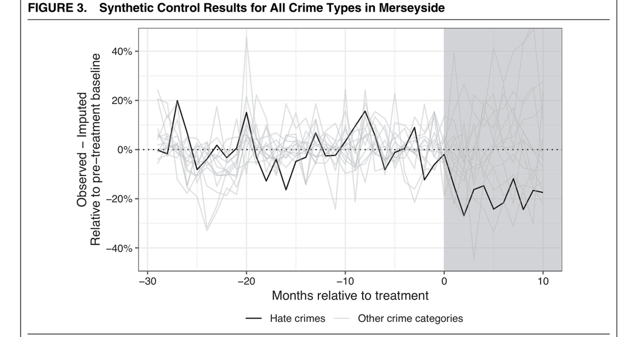

Decline is specific to hate crimes. Other Merseyside crime types do not show the same pattern.

## Figure 4a · Twitter: observed vs imputed

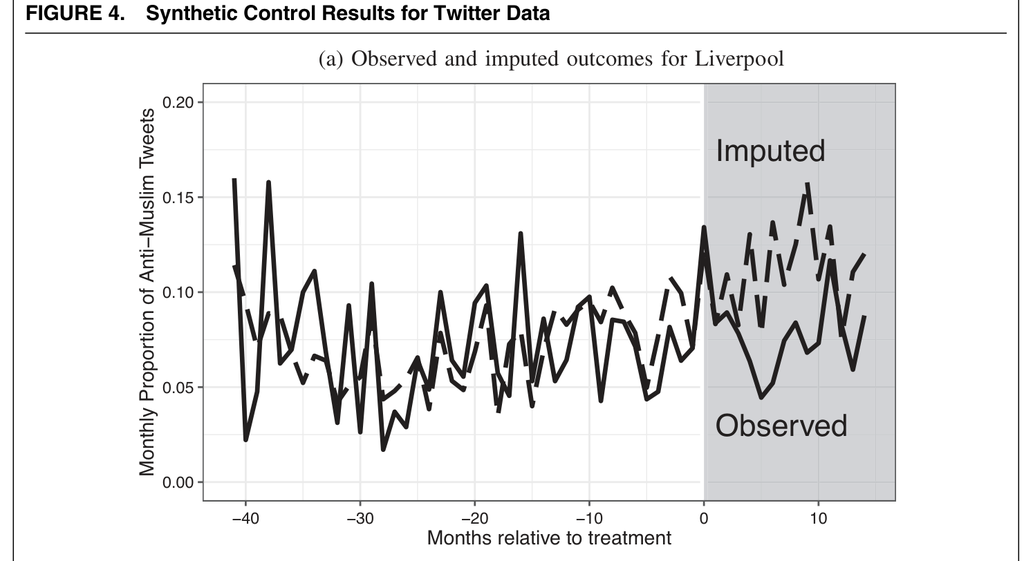

Liverpool fans’ anti-Muslim tweets fall ~50% below the imputed path after Salah arrives (3.8% vs 7.3%).

## Figure 4b · Twitter: ATT vs other clubs

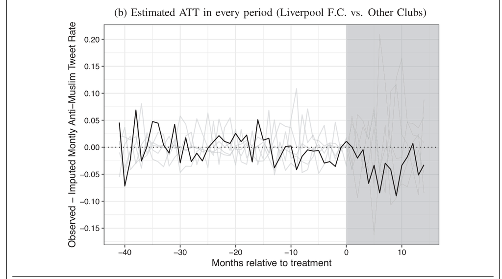

Liverpool’s ATT is more negative than placebo clubs. The effect is concentrated among LFC fans.

## Survey experiment · Design

- **Sample:** UK Facebook users who like Liverpool F.C.
- **Goal:** test the *generalization* step of parasocial contact. Does highlighting Salah’s Muslim identity improve attitudes toward Muslims more broadly?
- **Design:** 2×2 among treated fans (+ pure control): success vs failure × religiosity vs character + no Salah content
- **Outcomes:** Islam compatible with British values, feel common with Muslims, immigrants’ impact on the UK

## Figure 5 · Survey evidence

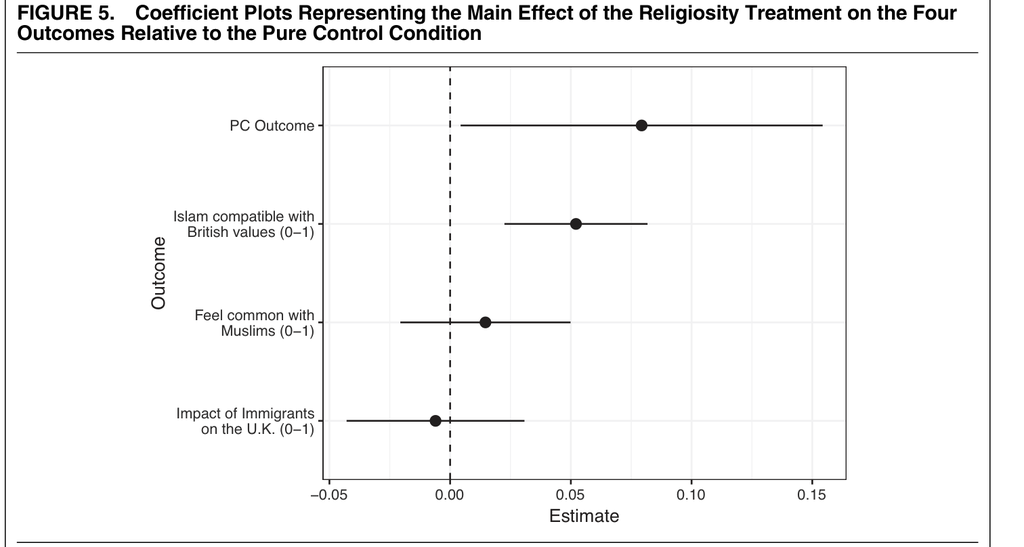

Religiosity cue raises pro-Muslim/“Islam compatible” attitudes. Weaker or null on commonality and immigrants.

## Discussion: demand & scope

**Scope condition:** the subset of cases/conditions under which a theory applies.

**Experimenter demand effects:** respondents infer the hypothesis and answer in the way they think the researcher wants.

“participant awareness of the purpose of the study can result in inaccurate self-reporting about prejudice.”

— Scacco & Warren (2018)

**Turn to a neighbor (≈4 min):**

1. In the case of Salah, many potentially favorable circumstances for parasocial contact might have driven the results. What do you think are these possible scope conditions?
2. Do you think this survey experiment is vulnerable to experimenter demand, and why?

In the case of Salah, many potentially favorable circumstances for parasocial contact might have driven the results. What do you think are these possible scope conditions?

## Conditional on performance?

[figure not shown]

> “I am a German when we win and an immigrant when we lose.”

Özil, quoted in Alrababa'h et al. (2021, p. 1124)

[figure not shown]

> “When things were going well, … they were calling me Romelu Lukaku, the Belgian striker. When things weren’t going well, they were calling me Romelu Lukaku, the Belgian striker of Congolese descent.”

Lukaku (2018), *The Players’ Tribune*; also in Alrababa'h et al. (2021, p. 1124)

[figure not shown]

> “You get a bit older and you realise that if you’re playing badly that’s when media starts saying ‘Nigerian-born’… when you do well you’re British; when you’re not doing so well you’re the Nigerian.”

Aluko, *Studio B Unscripted* with Afua Hirsch (Al Jazeera, 21 March 2020)

## Conditional on positive coverage?

[figure not shown]

[figure not shown]

## Conditional on not taking political stances?

[figure not shown]

Colin Kaepernick: kneeling during the U.S. national anthem (from 2016) against racial injustice and police violence

Do you think this survey experiment is vulnerable to experimenter demand, and why?

## Why this survey experiment is vulnerable

- Treatment primes Salah’s Muslim identity → outcomes ask about Islam/Muslims/immigrants
- The “tolerant” answer is easy to guess
- Recruited as Liverpool fans (“Help us research L.F.C.!”) → image management: look good for the club/researcher

Attitude shifts may be persuasion or performing tolerance.

Open Questions/Critique

## Open Questions/Critique

- How much of the survey effect is persuasion vs image management/experimenter demand among Liverpool fans?
- Would effects reverse if Salah played poorly, left, or took controversial political stances?

# Mousa (2020)

Research Question: Can intergroup contact build social cohesion after violent conflict?

## Experimental design

- **Setting:** amateur soccer leagues for displaced men in post-ISIS Northern Iraq
- **Sample:** Christian players randomized within league teams
- **Treatment:** ~3 Muslim teammates on an otherwise Christian squad (~25% Muslim)
- **Control:** all-Christian teams in the same leagues
- **Outcomes:** on-field vs off-field behaviors + attitudinal indices (weeks to months later)

Does this experiment fulfill the criteria for successful intergroup contact?

✓ Equal status

✓ Common goals

✓ Cooperative environment

✓ Institutional support

[figure not shown]

## Figure 1 · Behavioral results

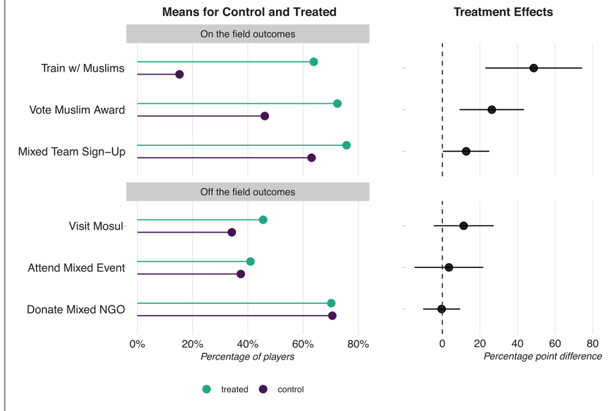

On-field: more likely to train with Muslims, vote a Muslim for sportsmanship, and sign up for a mixed team next season. Off-field: little change for a Mosul restaurant visit or a mixed social event.

How does Mousa (2020) measure if competition created hostility?

## Did competition create hostility?

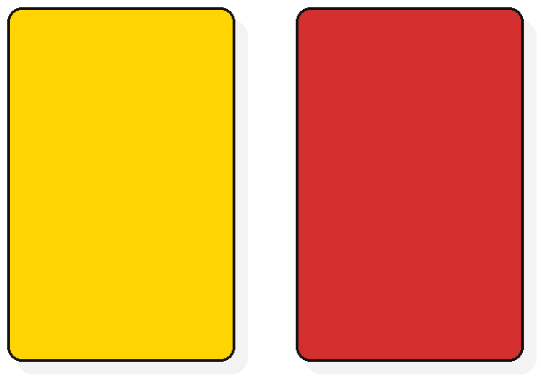

**Yellow/red cards as a proxy for on-pitch aggression:**

- Card rates do not differ by match type (mixed vs all-Christian)
- No extra hostility when mixed teams play all-Christian teams
- Referee’s religion also unrelated to carding

→ Competitive contact here does not look like backlash/escalation on the pitch.

Open Questions/Critique

# Scacco & Warren (2018)

Research Question: Can intergroup contact reduce prejudice and discrimination after violent conflict?

## Experimental design

- **Setting:** Kaduna, Nigeria, a city with a history of Christian–Muslim violence
- **Sample:** young Christian and Muslim men randomized into a 16-week computer-training program (UYVT)
- **Treatment:** three levels (program, classroom, and partner assignment)
- **Control:** pure control (no UYVT) plus homogeneous classrooms as a within-program contrast
- **Outcomes:** prejudice attitudes + behavioral games

Does this experiment fulfill the criteria for successful intergroup contact?

✓ Equal status

✓ Common goals

✓ Cooperative environment

✓ Institutional support

## Figure 1 · Experimental treatment arms

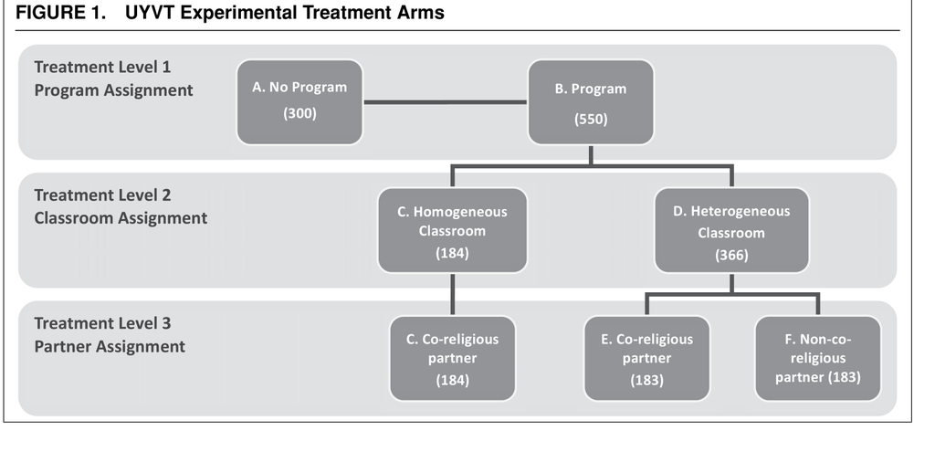

## Table 2 · Negative attributes

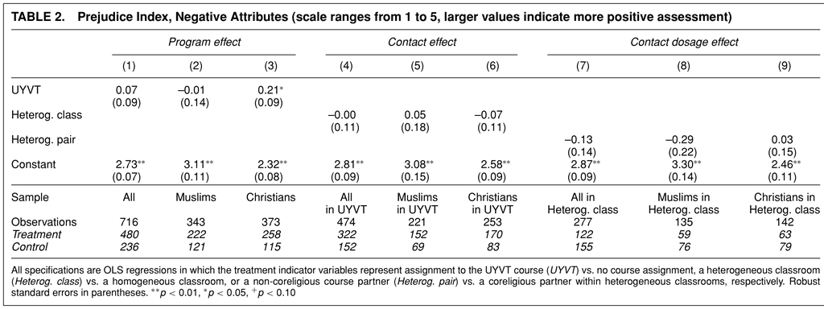

## Table 3 · Positive attributes

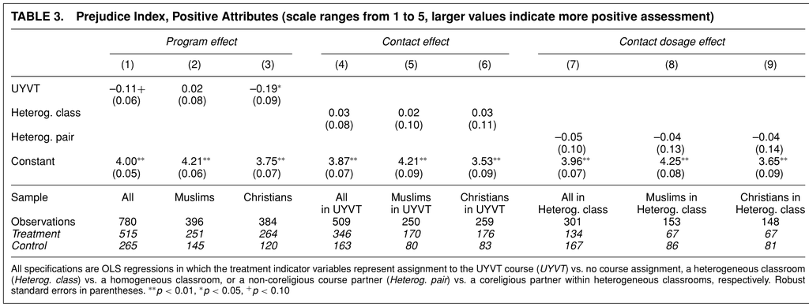

No contact effects on endorsement of positive out-group attributes. UYVT shows small negative effects in assigning positive attributes among Christians.

## Table 4 · Out-group evaluation

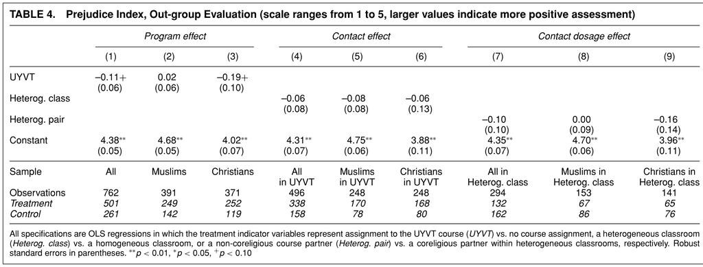

No contact effects on bipolar out-group evaluations (lazy–hardworking, etc.). UYVT shows a small negative effect among Christians.

## Behavioral outcomes · Dictator & destruction games

**Dictator game:** allocate money to another study participant, primed by first name (which signals religion) — measures generosity/discrimination in sharing.

**Destruction game:** each round, cross off the named opponent’s ₦50 notes and earn ₦10 per bill crossed off — small private gain at a larger cost to others.

- UYVT makes people more generous/less destructive overall
- Same-religion classes can *increase* discrimination (in-group bonding); mixed classes mainly stop that (esp. for Christians)
- An out-group learning partner adds little once the class is already mixed

Open Questions/Critique

# Synthesis

## The perfect Experiment

Design a hypothetical (para)social contact experiment to reduce prejudice/discrimination. Imagine unlimited resources (monetary, time, and (wo)manpower).

1

2

3

4

5

**Your task** (groups of 3–4, ≈20 min)

- Design a research poster for your experiment.
  1. Title + RQ
  2. Short description (including setting + sample)
  3. Design: treatment, control & randomization
  4. Outcomes (include attitudinal + behavioral)
  5. Are (para)social contact criteria met and how?
- Each group picks one person to pitch (**2 min**).
- Vote on the best poster!

Your turn!

# Outlook

## Next week: reducing hate crime II — persuasion

**Week 10** (Mon 16/Wed 18 Nov): reducing hate crime II — persuasion.

**Required readings**

- Broockman, D., & Kalla, J. (2016). Durably reducing transphobia: A field experiment on door-to-door canvassing. *Science*, 352(6282), 220–224.
- Adida, C. L., Lo, A., & Platas, M. R. (2018). Perspective taking can promote short-term inclusionary behavior toward Syrian refugees. *Proceedings of the National Academy of Sciences*, 115(38), 9521–9526.
- Hangartner, D., Gennaro, G., Alasiri, S., Bahrich, N., Bornhoft, A., Boucher, J., et al. (2021). Empathy-based counterspeech can reduce racist hate speech in a social media field experiment. *Proceedings of the National Academy of Sciences*, 118(50), Article e2116310118.
- Kalla, J. L., & Broockman, D. E. (2020). Reducing exclusionary attitudes through interpersonal conversation: Evidence from three field experiments. *American Political Science Review*, 114(2), 410–425.
- Kalla, J. L., & Broockman, D. E. (2023). Which narrative strategies durably reduce prejudice? Evidence from field and survey experiments supporting the efficacy of perspective-getting. *American Journal of Political Science*, 67(1), 185–204.

Weekly comments due **Sunday 15 Nov, 11:59 pm**.